# Dobre praktyki w wizualizacji

Szymon Gut

6 11 2021

# Rodzaj przeprowadzonego doświadczenia

Zdecydowałem się porównać odczytywanie danych z wykresu kołowego oraz słupkowego. Jak wszyscy dobrze wiemy, wykresów kołowych należy się wystrzegać. Postanowiłem więc sprawdzić czy i inni tak uważają.

# W jaki sposób przeprowadziłem doświadczenia?

Osobom badanym przesłałem link do ankiety, w której zadałem kilka pytań dotyczących tych dwóch typów wykresów. Łącznie na moment pisania raportu osób które odpowiedziały na pytania w ankiecie było 25. Potem wyniki ankiety pobrałem w rozszerzeniu .csv i przedstawiłem rezultaty na wykresach. Link do ankiety: https://forms.gle/RfrAqj1oJxMx7LXw9 .

# Jakie doświadczenia przeprowadziłem?

W ankiecie zostały postawione 4 pytania.

- Czy kiedykolwiek zajmowałeś się przetwarzaniem danych?

  Tutaj zamierzałem sprawdzić ile osób wcześniej zajmowało się już tym tematem.
- Który typ wykresu ułatwia odczytanie wartości maksymalnej?

  Tutaj usunąłem wszystkie wartości z wykresów i problem polegał na określeniu największej zamalowanej powierzchni koła, danym kolorem lub kolor najwyższego słupka.
- Który typ wykresu jest bardziej czytelny?

  Tutaj na obydwu wykresach zaznaczone są dokładne wartości i zadanie polega na wybraniu tego bardziej przejrzystego, który w szybszy sposób umożliwia odczytanie potrzebnych informacji.
- Który schemat kolorów ułatwia odczytywanie wartości?

  Tutaj zostały stworzone dwa schematy barw. Pierwszy przyjemne dla oka, ale również bardzo do siebie podobne oraz drugi w którym barwy już się juz troche bardziej różnią.

# Czy kiedykolwiek zajmowałeś się przetwarzaniem danych?

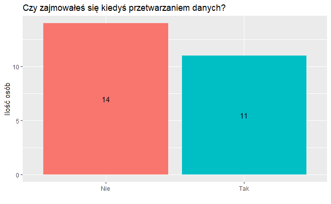

Jak widzimy na powyższym wykresie dane rozkładają się w miarę równomiernie. Nie ankietowałem jednak osób z naszego kierunku (wynik ankiety byłby oczywisty), więc osoby które zaznaczyły odpowiedź, że zajmowały się kiedyś przetwarzaniem danych, wcale nie musiały jakoś głęboko zagłębiać się w zagadnienia data science i wizualizację danych, przez co nie każdy z nich mógł słyszeć o minusach wykresów kołowych. Uważam więc, że wyniki eksperymentów można uznać za miarodajne.

# Z którego wykresu łatwiej odczytać wartość maksymalną?

W pierwszym eksperymencie zostało postawione pytanie, z którego typu wykresu łatwiej odczytać wartość maksymalną.

Wykresy wyglądały następująco:

- słupkowy:

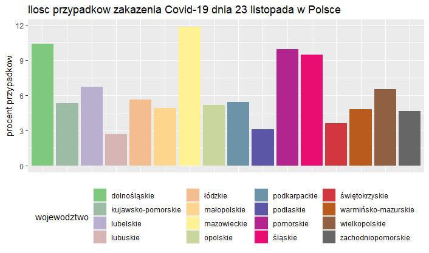

- kołowy:

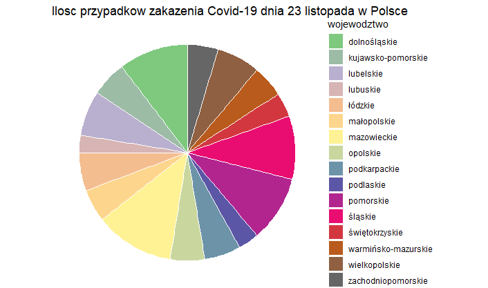

Wynik nie będzie tutaj zaskoczeniem, a został on zaprezentowany na zdjęciu poniżej.

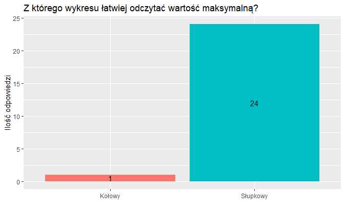

# Który z wykresów jest bardziej przejrzysty?

Znając dobre praktyki w wizualizacji, tutaj także nie było zaskoczenia. Tutaj również tylko jedna osoba odpowiedziała, że według niej łatwiej odczytywać dane z wykresu kołowego.

Wykresy wyglądały tak:

- słupkowy:

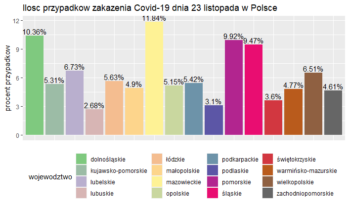

- kołowy:

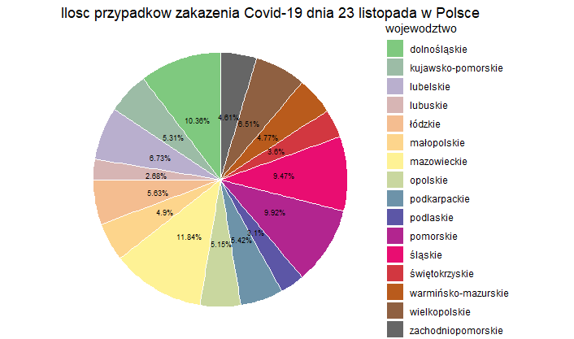

Wyniki prezentują się następująco:

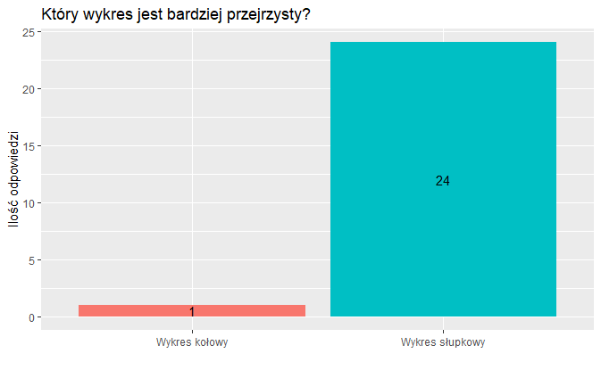

# Czy schemat kolorów wpływa na czytelność wykresu?

Jak się okazało schemat barw też ma duży wpływ na odczytywanie danych. Barwy pierwszego wykresu były bardziej zbliżone do siebie niż na tym drugim i wg wiekszości badanych sprawiały one, że wykres stawał się mniej czytelny.

Wykresy prezentowały się następująco:

- Pierwszy:

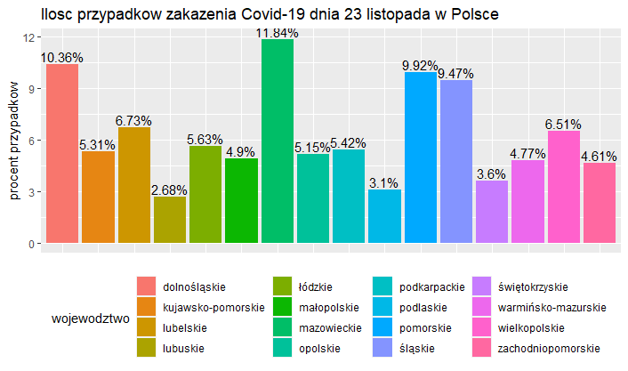

- Drugi:

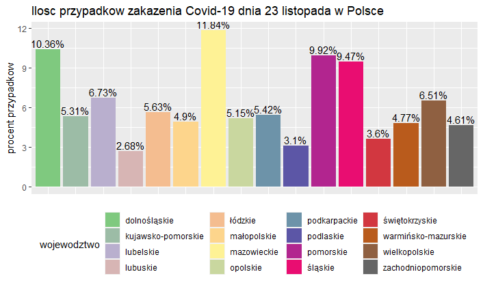

Wyniki eksperymentu natomiast prezentują się tak:

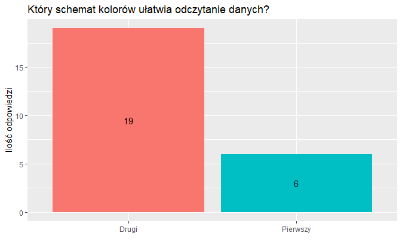

# Przedstawienie wyników eksperymentów również w postaci tabeli

dane pochodzą z wyniku odpowiedzi w autorskiej ankiecie dostępnej tutaj :[<https://forms.gle/RfrAqj1oJxMx7LXw9>](https://forms.gle/RfrAqj1oJxMx7LXw9)

|  | **Który typ wykresu ułatwia odczytanie wartości maksymalnej?** | **Który wykres jest bardziej przejrzysty?** | Który schemat kolorów ułatwia odczytanie danych z wykresu? |
| --- | --- | --- | --- |
| ilość wszystkich ankietowanych | 25 | 25 | 25 |
| osoby które uznały powszechne dobre prakyki za słuszne | 24 | 24 | 19 |
| Osoby, które zaprzeczyły dobrym praktykom w wyzualizacji danych | 1 | 1 | 6 |

# Kod napisany w celu stworzenia wszystkich wykresów przedstawionych w powyższym raporcie.

## Wczytanie bibliotek oraz głównej ramki danych

```r
library(ggplot2)
library(dplyr)
library(RColorBrewer)
df <- read.csv("raport.csv", sep = ";", encoding = "UTF-8")
ankieta <- read.csv("ankieta.csv", encoding = "UTF-8")
df <- df %>% filter(wojewodztwo != "Cały kraj")
df <- df %>%
  arrange(desc(wojewodztwo)) %>%
  mutate(prop = (liczba_przypadkow / sum(df$liczba_przypadkow) *100)) %>%
  mutate(ypos = cumsum(prop)- 0.55*prop)
par(mar=c(0,0,2,2))
nb.cols <- 16
```

## Kod użyty w paragrafie Czy kiedykolwiek zajmowałeś się przetwarzaniem danych?

```r
czy_zajmowales_sie_datascience <- ankieta %>%
count(Czy.kiedykolwiek.zajmowałeś.się.przetwarzaniem.danych.)

p <- ggplot(czy_zajmowales_sie_datascience,aes(x = Czy.kiedykolwiek.zajmowałeś.się.przetwarzaniem.danych.,
                                               y = n,
                                               fill = Czy.kiedykolwiek.zajmowałeś.się.przetwarzaniem.danych.)) +
  geom_col()+
  guides(fill = FALSE) +
  geom_text(aes(label = n),
            position = position_stack(vjust = .5))+
  labs(title = "Czy zajmowałeś się kiedyś przetwarzaniem danych?",
        x = "",
        y = "Ilość osób")
```

## Kod użyty w paragrafie: Który z wykresów jest bardziej przejrzysty?

### Wykres słupkowy:

```r
pl <- ggplot(df, aes(x = wojewodztwo, y = prop, fill = wojewodztwo)) +
  geom_col(position = "dodge") + theme(axis.title.x = element_blank(), axis.ticks.x = element_blank(), axis.text.x = element_blank()) +
  theme(legend.position = "bottom") +
  geom_text(aes(label=paste0(round(prop, 2), "%")), position = position_dodge(width = 0.9), vjust = -0.25) +
  labs(title = "Ilosc przypadkow zakazenia Covid-19 dnia 23 listopada w Polsce", y = "procent przypadkow")+
  scale_fill_manual(values = colorRampPalette(brewer.pal(12, "Accent"))(nb.cols))
```

### Wykres kołowy :

```r
p <- ggplot(df, aes(x="", y=prop, fill=wojewodztwo)) +
  geom_bar(stat="identity", width=1, color="white") +
  coord_polar("y", start=0) +
  theme_void() +
  geom_text(aes(y = ypos, label = paste0(round(prop, 2), "%")), color = "black", size=2.5)+
  labs(title = "Ilosc przypadkow zakazenia Covid-19 dnia 23 listopada w Polsce")+
  scale_fill_manual(values = colorRampPalette(brewer.pal(12, "Accent"))(nb.cols))
```

### Wizualizacja wyniku:

```r
ktory_wykres_najbardziej_przejrzysty <- ankieta %>%
  count(Który.wykres.jest.bardziej.przejrzysty.łatwiej.odczytać.z.niego.dane..)
p2 <- ggplot(ktory_wykres_najbardziej_przejrzysty,aes(x = Który.wykres.jest.bardziej.przejrzysty.łatwiej.odczytać.z.niego.dane..,
                                                      y = n,
                                                      fill = Który.wykres.jest.bardziej.przejrzysty.łatwiej.odczytać.z.niego.dane..)) +
  geom_col()+
  guides(fill = FALSE) +
  geom_text(aes(label = n),
            position = position_stack(vjust = .5))+
  labs(title = "Który wykres jest bardziej przejrzysty?",
       x = "",
       y = "Ilość odpowiedzi")
```

## Kod użyty w paragrafie: Z którego wykresu łatwiej odczytać wartość maksymalną?

### Wykres słupkowy:

```r
pl1 <- ggplot(df, aes(x = wojewodztwo, y = prop, fill = wojewodztwo)) +
  geom_col(position = "dodge") + theme(axis.title.x = element_blank(), axis.ticks.x = element_blank(), axis.text.x = element_blank()) +
  theme(legend.position = "bottom") +
  labs(title = "Ilosc przypadkow zakazenia Covid-19 dnia 23 listopada w Polsce", y = "procent przypadkow")+
  scale_fill_manual(values = colorRampPalette(brewer.pal(12, "Accent"))(nb.cols))
```

### Wykres kołowy:

```r
p1 <- ggplot(df, aes(x="", y=prop, fill=wojewodztwo)) +
  geom_bar(stat="identity", width=1, color="white") +
  coord_polar("y", start=0) +
  theme_void() +
  labs(title = "Ilosc przypadkow zakazenia Covid-19 dnia 23 listopada w Polsce")+
  scale_fill_manual(values = colorRampPalette(brewer.pal(12, "Accent"))(nb.cols))
```

### Wykres wynikowy:

```r
z_ktorego_latwiej_max <- ankieta %>%
  count(Z.którego.wykresu.łatwiej.odczytać.wartość.maksymalną)
z_ktorego_latwiej_max$Z.którego.wykresu.łatwiej.odczytać.wartość.maksymalną[z_ktorego_latwiej_max$Z.którego.wykresu.łatwiej.odczytać.wartość.maksymalną == "A"] = "Kołowy"
z_ktorego_latwiej_max$Z.którego.wykresu.łatwiej.odczytać.wartość.maksymalną[z_ktorego_latwiej_max$Z.którego.wykresu.łatwiej.odczytać.wartość.maksymalną == "B"] = "Słupkowy"

p1 <- ggplot(z_ktorego_latwiej_max,aes(x = Z.którego.wykresu.łatwiej.odczytać.wartość.maksymalną,
                                       y = n,
                                       fill = Z.którego.wykresu.łatwiej.odczytać.wartość.maksymalną)) +
  geom_col()+
  guides(fill = FALSE) +
  geom_text(aes(label = n),
            position = position_stack(vjust = .5))+
  labs(title = "Z którego wykresu łatwiej odczytać wartość maksymalną?",
       x = "",
       y = "Ilość odpowiedzi")
```

## Kod użyty w paragrafie: Czy schemat kolorów wpływa na czytelność wykresu?

### Wykres z podobnymi barwami:

```r
pl2 <- ggplot(df, aes(x = wojewodztwo, y = prop, fill = wojewodztwo)) +
  geom_col(position = "dodge") + theme(axis.title.x = element_blank(), axis.ticks.x = element_blank(), axis.text.x = element_blank()) +
  theme(legend.position = "bottom") +
  geom_text(aes(label=paste0(round(prop, 2), "%")), position = position_dodge(width = 0.9), vjust = -0.25) +
  labs(title = "Ilosc przypadkow zakazenia Covid-19 dnia 23 listopada w Polsce", y = "procent przypadkow")
```

### Wykres z barwami bardziej rozróżnialnymi:

```r
pl <- ggplot(df, aes(x = wojewodztwo, y = prop, fill = wojewodztwo)) +
  geom_col(position = "dodge") + theme(axis.title.x = element_blank(), axis.ticks.x = element_blank(), axis.text.x = element_blank()) +
  theme(legend.position = "bottom") +
  geom_text(aes(label=paste0(round(prop, 2), "%")), position = position_dodge(width = 0.9), vjust = -0.25) +
  labs(title = "Ilosc przypadkow zakazenia Covid-19 dnia 23 listopada w Polsce", y = "procent przypadkow")+
  scale_fill_manual(values = colorRampPalette(brewer.pal(12, "Accent"))(nb.cols))
```

### Wykres wynikowy:

```r
ktory_schemat_kolorow <- ankieta %>%
  count(Który.schemat.kolorów.ułatwia.odczytanie.danych.dla.poszczególnych.województw.)
ktory_schemat_kolorow$Który.schemat.kolorów.ułatwia.odczytanie.danych.dla.poszczególnych.województw.[ktory_schemat_kolorow$Który.schemat.kolorów.ułatwia.odczytanie.danych.dla.poszczególnych.województw. == "1"] = "Pierwszy"
ktory_schemat_kolorow$Który.schemat.kolorów.ułatwia.odczytanie.danych.dla.poszczególnych.województw.[ktory_schemat_kolorow$Który.schemat.kolorów.ułatwia.odczytanie.danych.dla.poszczególnych.województw. == "2"] = "Drugi"
p3 <- ggplot(ktory_schemat_kolorow, aes(x = Który.schemat.kolorów.ułatwia.odczytanie.danych.dla.poszczególnych.województw.,
y = n,
fill =
  Który.schemat.kolorów.ułatwia.odczytanie.danych.dla.poszczególnych.województw.))+
  geom_col()+
  guides(fill = FALSE) +
  geom_text(aes(label = n),
            position = position_stack(vjust = .5))+
  labs(title = "Który schemat kolorów ułatwia odczytanie danych?",
       x = "",
       y = "Ilość odpowiedzi")
```

# Podsumowanie

Co nie będzie dużym zaskoczeniem, odpowiedzi większości ankietowanych jasno wskazały, że dobre praktyki opracowane lata temu, są słuszne i znacznie wpływają na odczytywanie danych. Wykres kołowy znacznie ciężej się odczytuje (został wskazany tylko przez jedną osobę) i nie ważne jest tutaj czy umieścimy na nim również wartości procentowe. Barwy użyte na wykresach również mają duży wpływ na przejrzystość wykresu i jak większość osób uznała, barwy które bardziej się między sobą różnią, ułatwiają odczytywanie danych.